# Module 5 exercises

```r
library(ggplot2) #load ggplot
library(ggthemes) #load themes package for ggplot
theme_set(theme_tufte()) # a theme I like.

#set some options that I like
theme_update(plot.title = element_text(hjust = 0.5),
             axis.line.x = element_line(color="black", size = 1),
             axis.line.y = element_line(color="black", size = 1),
             text=element_text(size=20),
             axis.text=element_text(size=15)) #center all titles and and axis lines
```

# Exercise 5A

## Calculating and plotting correlations

Below is the correlation plot of the sleep dataset from lecture:

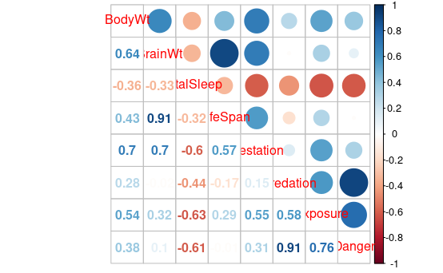

```r
sleep.dat <- read.csv(file="../Data/MammalSleep.csv")

library(corrplot)
M <- cor(sleep.dat[,3:10], use="pairwise.complete") #extract numeric responses
corrplot.mixed(M)
```

In lecture we discussed strong correlations between response and predictor. What are the top 3 strongest correlations among the predictor variables in this dataset?

### The strongest correlations cmong predictors are Danger-Predation, Lifespan-Brainweight, and Danger-Exposure

# Exercise 5B

## Simple linear regression

We are going to repeat the analysis produced in class but instead of using the predictor of `BrainWt` we will transform it and use `log(BrainWt)`. Plug in `log(BrainWt)` to the call in `lm`. What is the R-squared value of this model and how does it compare to the model I presented in class? How about the diagnositic plots, do they look different than the model I presented in class?

```r
#code here
sleep.dat <- read.csv(file="../Data/MammalSleep.csv")
sleep.lm  <- lm(TotalSleep ~ log(BrainWt), data=sleep.dat)
summary(sleep.lm)
```

```
Call:
lm(formula = TotalSleep ~ log(BrainWt), data = sleep.dat)

Residuals:
   Min     1Q Median     3Q    Max
-6.488 -3.178  0.152  2.434  7.612

Coefficients:
             Estimate Std. Error t value Pr(>|t|)
(Intercept)   13.6251     0.9938  13.711 7.35e-16 ***
log(BrainWt)  -0.9983     0.2788  -3.581    0.001 **
---
Signif. codes:  0 ‘***’ 0.001 ‘**’ 0.01 ‘*’ 0.05 ‘.’ 0.1 ‘ ’ 1

Residual standard error: 3.934 on 36 degrees of freedom
  (4 observations deleted due to missingness)
Multiple R-squared:  0.2626,    Adjusted R-squared:  0.2422
F-statistic: 12.82 on 1 and 36 DF,  p-value: 0.001004
```

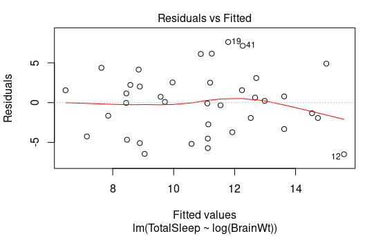

```r
plot(sleep.lm, which=1)
```

### The R-squared value of this model is 0.26, over twice the original model. The diagnostic figures look better as well.

# Exercise 5C

## Multiple linear regression

1. Read in the dataset, `monet.csv`. Build a model that includes the effects of SIGNED (whether the painting was signed) and painting SIZE. Based on this, are signed paintings more or less valuable than unsigned paintings?

```r
#code here
monet.dat <- read.csv(file="../Data/monet.csv")
monet.mod  <- lm(PRICE ~ SIZE + SIGNED, data=monet.dat)

summary(monet.mod)
```

```
Call:
lm(formula = PRICE ~ SIZE + SIGNED, data = monet.dat)

Residuals:
    Min      1Q  Median      3Q     Max
-8.8681 -2.1659 -1.1976  0.5584 28.4048

Coefficients:
              Estimate Std. Error t value Pr(>|t|)
(Intercept) -1.2192965  0.5722946  -2.131   0.0337 *
SIZE         0.0024839  0.0002876   8.636  < 2e-16 ***
SIGNEDYes    2.4026001  0.5069449   4.739 2.92e-06 ***
---
Signif. codes:  0 ‘***’ 0.001 ‘**’ 0.01 ‘*’ 0.05 ‘.’ 0.1 ‘ ’ 1

Residual standard error: 3.95 on 427 degrees of freedom
Multiple R-squared:  0.1645,    Adjusted R-squared:  0.1606
F-statistic: 42.04 on 2 and 427 DF,  p-value: < 2.2e-16
```

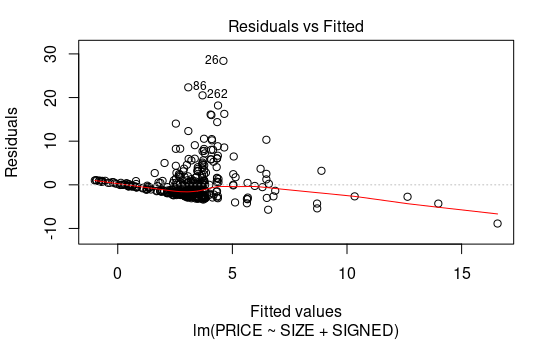

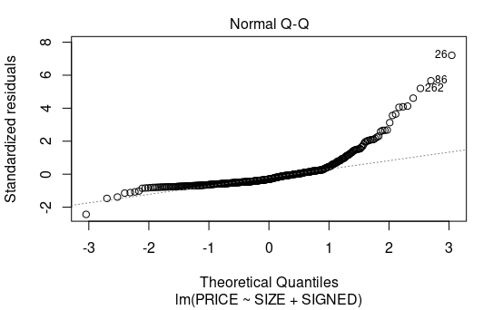

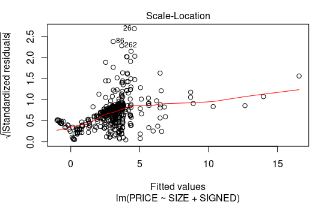

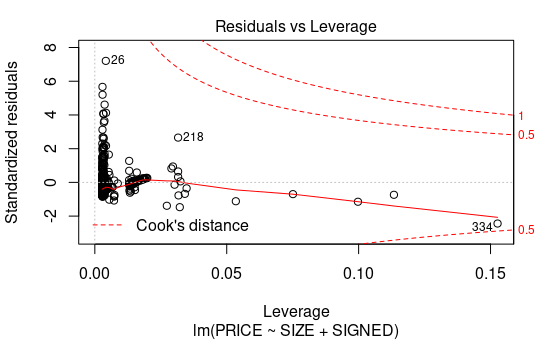

```r
plot(monet.mod)
```

### This model predicts that signed paintings are more expensive than unsigned paintings.

Load the `sjPlot` library and use the function `plot_model` to plot PRICE predictions against SIZE and SIGNED. Does the plot agree with your interpretation of the parameter estimates?

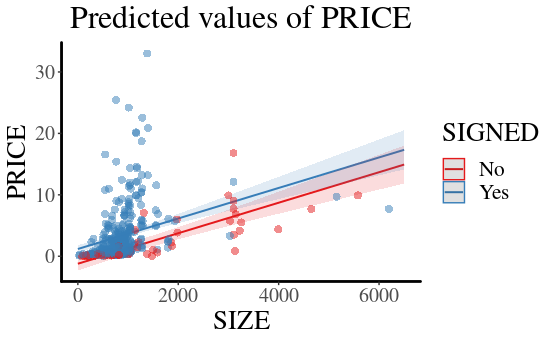

```r
#code here
library(sjPlot)
plot_model(monet.mod, type="pred", terms=c("SIZE", "SIGNED"), show.data=TRUE)
```

# Exercise 5D

## Run an ANOVA model

Run an ANOVA on the model you defined above. What does this F-test tell you about whether there is a difference between signed and unsigned paintings?

```r
#code here
summary(aov(monet.mod))
```

```
             Df Sum Sq Mean Sq F value   Pr(>F)
SIZE          1    961   961.4   61.62 3.39e-14 ***
SIGNED        1    350   350.4   22.46 2.92e-06 ***
Residuals   427   6662    15.6
---
Signif. codes:  0 ‘***’ 0.001 ‘**’ 0.01 ‘*’ 0.05 ‘.’ 0.1 ‘ ’ 1
```

### The p-value suggests that there is a difference between the signed and unsigned paintings. Because this factor only has two levels it is identical to the t-test.